# **Basic Metric Analysis**

# VISUAL ANALYSIS

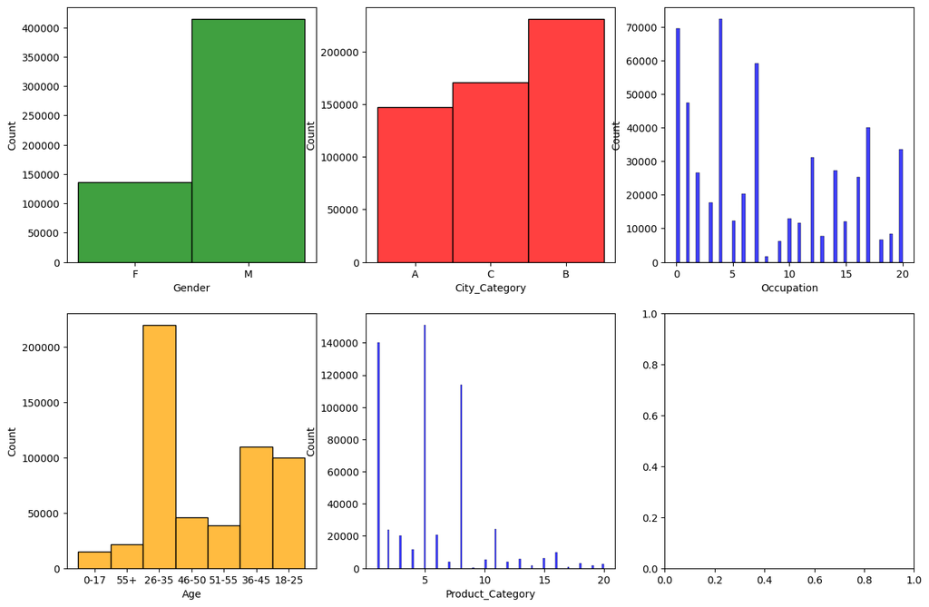

```python
fig, axis = plt.subplots(nrows=2, ncols=3, figsize=(15,10))
sns.histplot(data=df, x='Gender', ax=axis[0,0],color='green')
sns.histplot(data=df, x='City_Category', ax=axis[0,1],color = "red")
sns.histplot(data=df, x='Occupation', ax=axis[0,2],color='blue')
sns.histplot(data=df, x='Age', ax=axis[1,0],color='orange')
sns.histplot(data=df, x='Product_Category', ax=axis[1,1],color='blue')
plt.show()
```

INSIGHTS:

- The product categories 5, 1, and 8 have the highest purchase.
- Females are purchasing way too low in number than males.
- Most customers are from the City B followed by C and then A.
- Most of the customers age group are from interval 26-35.

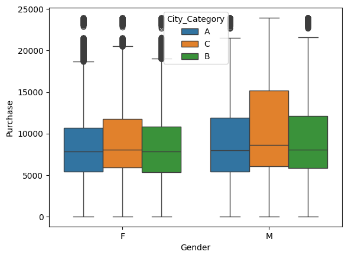

```python
sns.boxplot(data=df, x='Gender',y ='Purchase',hue='City_Category')
```

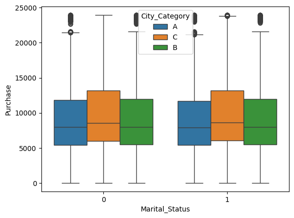

```python
sns.boxplot(data=df, x='Marital_Status',y ='Purchase',hue='City_Category')
```

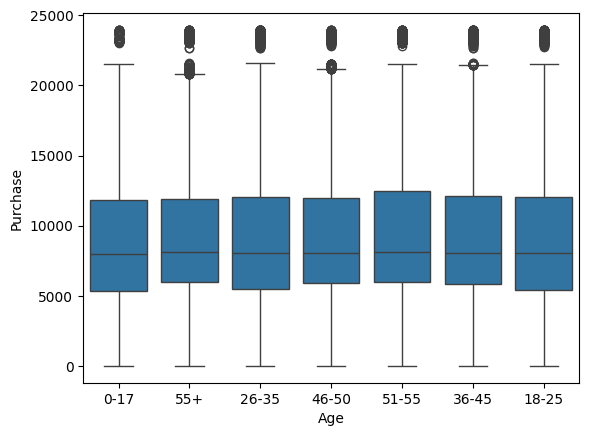

```python
sns.boxplot(data=df, x='Age',y ='Purchase')
```

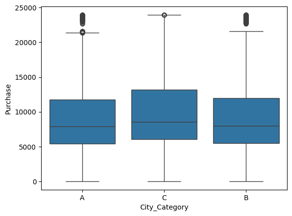

```python
sns.boxplot(data=df, x='City_Category',y ='Purchase')
```

**INSIGHTS:**

- *Gender vs. Purchase*

> a) The median for males and females is almost equal.

> b) Females have more outliers compared to males.

> c) Males purchased more compared to females.

> d) Males and Females from City category C are purchasing more.
- *Martial Status vs. Purchase*

> a) The median for married and single people is almost equal.

> b) Outliers are present in both records.
- *Age vs. Purchase*

> a) The median for all age groups is almost equal.

> b) Outliers are present in all age groups.
- *City Category vs. Purchase*

> a) The C city region has very low outliers compared to other cities.

> b) A and B city region medians are almost the same.

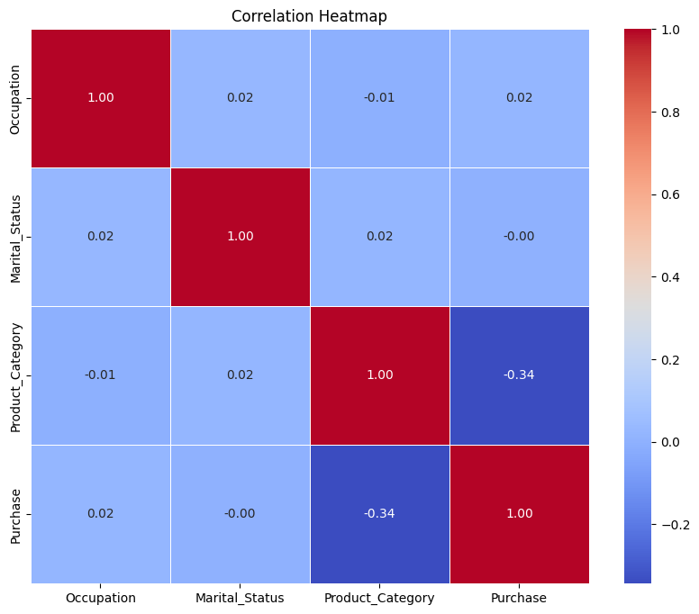

```python
features_to_correlate = ['Gender', 'Age', 'Occupation', 'City_Category','Stay_In_Current_City_Years','Marital_Status','Product_Category','Purchase']

# Subset the DataFrame with the selected features
subset_df = df[features_to_correlate]

# Compute the correlation matrix
correlation_matrix = subset_df.corr()

# Plot a heatmap of the correlation matrix
plt.figure(figsize=(10, 8))
sns.heatmap(correlation_matrix, annot=True, cmap='coolwarm', fmt='.2f', linewidths=0.5)
plt.title('Correlation Heatmap')
plt.show()
```

# Missing Values and Outliers Detection

```python
df.isna().sum()
```

```
User_ID                       0
Product_ID                    0
Gender                        0
Age                           0
Occupation                    0
City_Category                 0
Stay_In_Current_City_Years    0
Marital_Status                0
Product_Category              0
Purchase                      0
dtype: int64
```

INSIGHTS: There are no null values in the dataset

```python
q1 = df["Purchase"].quantile(0.25)
q3 = df["Purchase"].quantile(0.75)
IQR = q3-q1
outliers = df["Purchase"][((df["Purchase"]<(q1-1.5*IQR)) | (df["Purchase"]>(q3+1.5*IQR)))]
print("number of outliers: "+ str(len(outliers)))
print("max outlier value:"+ str(outliers.max()))
print("min outlier value: "+ str(outliers.min()))
```

```
number of outliers: 2677
max outlier value:23961
min outlier value: 21401
```

# Are women spending more money per transaction than men?

```python
avg_by_gender = df.groupby('Gender')['Purchase'].mean()
print(f'Average purchase of male and female : \n{avg_by_gender}')
```

```
Average purchase of male and female :
Gender
F    8734.565765
M    9437.526040
Name: Purchase, dtype: float64
```

INSIGHTS:

- Males are spending more money than females.
- Reason can be that because there are more males customers approxx 3/4th of the total customers.
- this indicates that at walmart females specific products are very less.

# Confidence intervals and distribution of the mean of the expenses by female and male customers

```python
import numpy as np
female_customers=df[df['Gender']=='F']
male_customers=df[df['Gender']=='M']
def calculate_ci_bootstrap(data, n_bootstrap, confidence_level=0.95):

    sample_means = np.zeros(n_bootstrap)

    for i in range(n_bootstrap):
        bootstrap_sample = np.random.choice(data, size=len(data), replace=True)
        sample_means[i] = np.mean(bootstrap_sample)


    alpha = 1 - confidence_level
    lower_percentile = alpha / 2 * 100
    upper_percentile = (1 - alpha / 2) * 100
    ci_lower = np.percentile(sample_means, lower_percentile)
    ci_upper = np.percentile(sample_means, upper_percentile)

    return ci_lower, ci_upper, sample_means

n_bootstrap = 1000
confidence_level = 0.95

ci_lower_female, ci_upper_female, sample_means_female = calculate_ci_bootstrap(female_customers['Purchase'], n_bootstrap, confidence_level)


ci_lower_male, ci_upper_male, sample_means_male = calculate_ci_bootstrap(male_customers['Purchase'], n_bootstrap, confidence_level)

print("Confidence Intervals for Average Spending of Female Customers:")
print("Lower Bound:", ci_lower_female)
print("Upper Bound:", ci_upper_female)
print()

print("Confidence Intervals for Average Spending of Male Customers:")
print("Lower Bound:", ci_lower_male)
print("Upper Bound:", ci_upper_male)
```

```
Confidence Intervals for Average Spending of Female Customers:
Lower Bound: 8709.017933089854
Upper Bound: 8760.766168479262

Confidence Intervals for Average Spending of Male Customers:
Lower Bound: 9421.990009631656
Upper Bound: 9452.942462927782
```

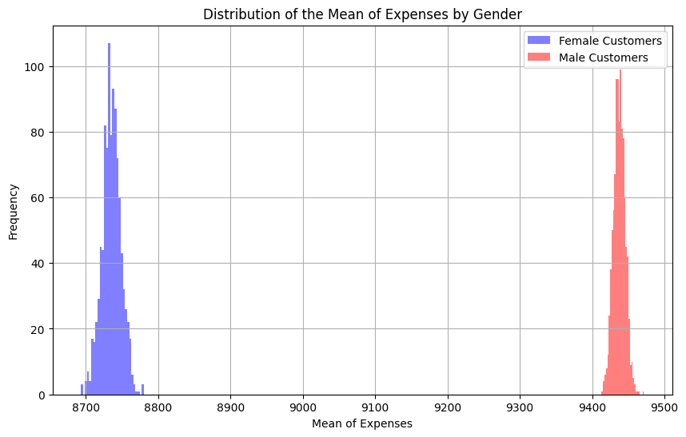

```python
import matplotlib.pyplot as plt

plt.figure(figsize=(10, 6))

plt.hist(sample_means_female, bins=30, color='blue', alpha=0.5, label='Female Customers')

plt.hist(sample_means_male, bins=30, color='red', alpha=0.5, label='Male Customers')

plt.xlabel('Mean of Expenses')
plt.ylabel('Frequency')
plt.title('Distribution of the Mean of Expenses by Gender')
plt.legend()
plt.grid(True)
plt.show()
```

INSIGHTS: